# Project 2

## BOGAZICI UNIVERSITY FALL’19

## IE 423 QUALITY ENGINEERING

## Quality Control on Images

Due Date: 04.11.2019

Instructor: Mustafa Baydogan

Group Members:  
Sinan Demirhan  
Abdullah Yildiz  
Ogulcan Ece  
Merve Keskin  
Merve Gülsüm Kiratli  
Oguzhan Murat TOSUN

## Part 1

### Question a-)

For each row of your image, construct an appropriate chart for monitoring the mean and variance. Find the pixels that are out of control. After finding those pixels, change the value of these pixels to zero (i.e. black color). Display the new image and original image in a plot. What are your observations? Comment on your findings.

```r
library("EBImage")
require(stats)
library("imager")
library(ggplot2)
getwd()
```

```
## [1] "C:/Users/Sinan/Desktop"
```

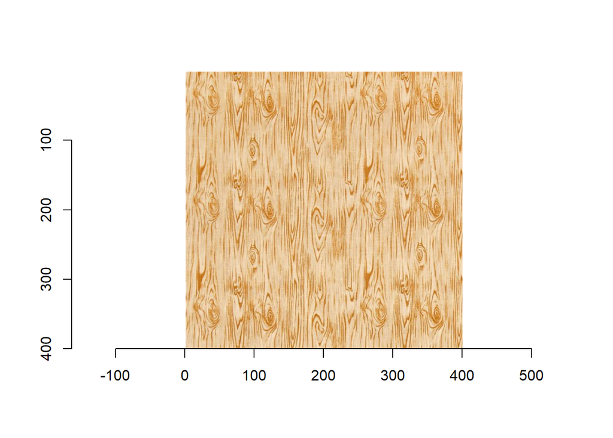

```r
setwd("C:/Users/Sinan/Desktop")
im <- load.image('group_4.jpg')
plot(im)
```

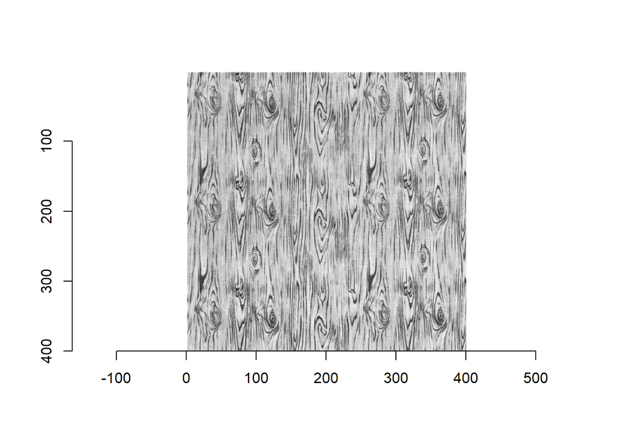

```r
img_g<-grayscale(im)
plot(img_g)
```

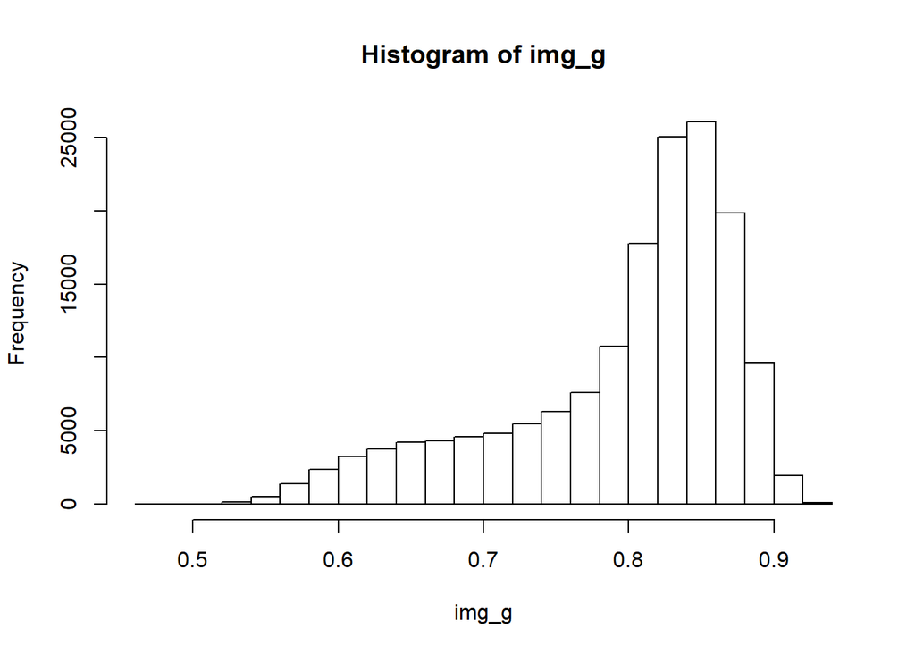

```r
hist(img_g)
```

```r
mean_std_of_rows<-array(0,dim = c(400,2))
mean_std_of_columns<-array(0,dim = c(400,2))
```

```r
for (i in c(1:400)) {
  mean_std_of_rows[i,]<-c(mean(img_g[i,]),sqrt(var(img_g[i,])))
  mean_std_of_columns[i,]<-c(mean(img_g[,i]),sqrt(var(img_g[,i])))
}
```

We constructed 2 Dimensional array for mean and std values of rows and columns  
We collected each row and colunm means and std value in this 2 dimensional array  
First column of this array gives the mean values  
Second column of this array gives the std values for each sample.

```r
mean_std_of_columns<-data.frame(mean_std_of_columns)
mean_std_of_rows<-data.frame(mean_std_of_rows)
```

```r
bounds<-c(0.4,1.2)
```

### We plotted the control charts for the first 2 row as an example.Because the number of rows is too large ,we didn’t plot all of them.

```r
par(mfrow = c(1,2))
plot(img_g[,1],type = "line",ylim = bounds,ylab = "Pixel values",xlab ="Column numbers in the first row")+
  abline(h=mean_std_of_rows[1,1]+3*mean_std_of_rows[1,2],col="blue") +
  abline(h=mean_std_of_rows[1,1]-3*mean_std_of_rows[1,2],col="blue") +
  abline(h=mean_std_of_rows[1,1],col="red")
```

```
## integer(0)
```

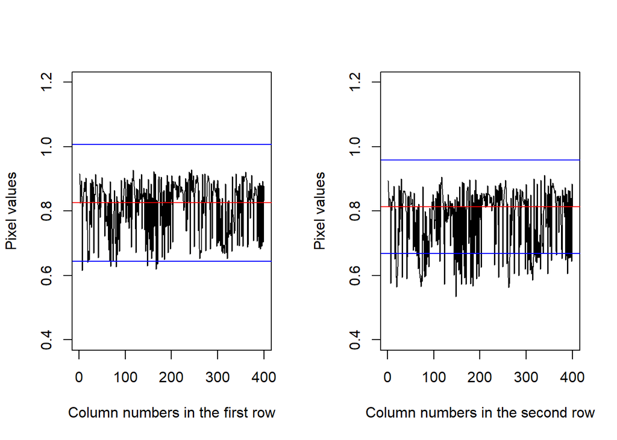

```
## integer(0)
```

```r
plot(img_g[,2],type = "line",ylim = bounds,ylab = "Pixel values",xlab ="Column numbers in the second row")+
  abline(h=mean_std_of_rows[2,1]+3*mean_std_of_rows[2,2],col="blue") +
  abline(h=mean_std_of_rows[2,1]-3*mean_std_of_rows[2,2],col="blue") +
  abline(h=mean_std_of_rows[2,1],col="red")
```

We know that in the X bar Charts;  
UCL = mean(Xbar) + K * sigma(s)  
LCL = mean(Xbar) - K * sigma(s)

```r
image_new_for_rows<-img_g

for(i in c(1:400)){
  UCL<-mean_std_of_rows[i,1]+3*mean_std_of_rows[i,2]
  LCL<-mean_std_of_rows[i,1]-3*mean_std_of_rows[i,2]
  for(j in c(1:400)){
    if((img_g[j,i]<LCL) || (img_g[j,i]> UCL)){
      image_new_for_rows[j,i]<-0
    }
  }
}
```

X bar Chart

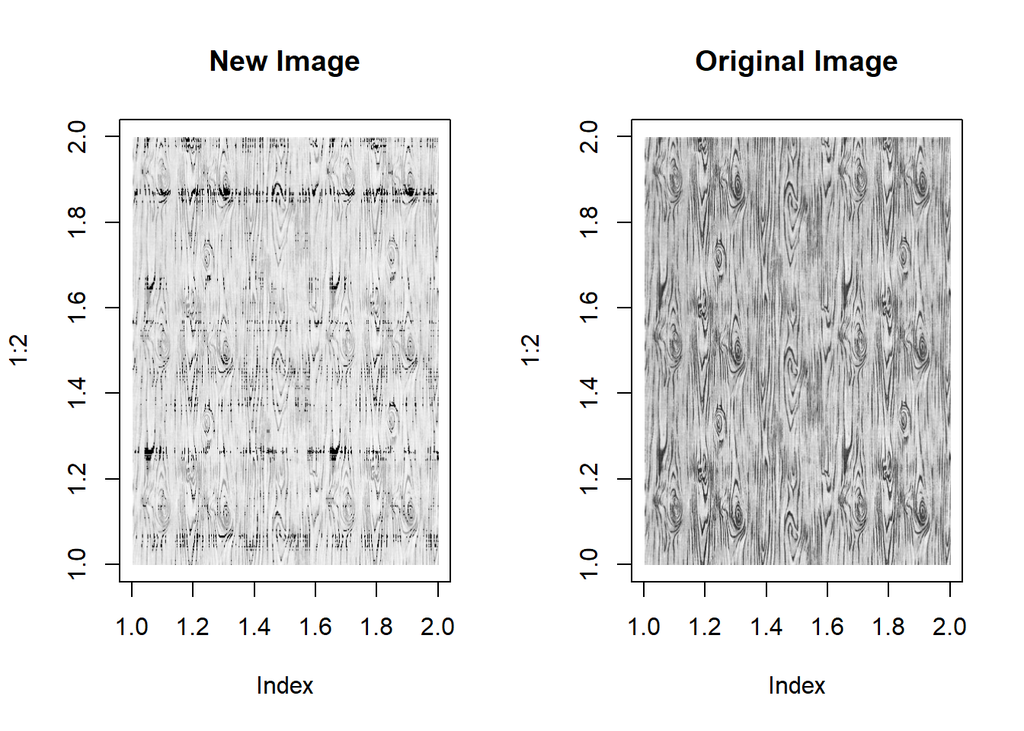

```r
par(mfrow = c(1,2))
plot(1:2, type='n',main = "New Image")
rasterImage(image_new_for_rows, 1, 1, 2, 2)
plot(1:2, type='n',main = "Original Image")
rasterImage(img_g, 1, 1, 2, 2)
```

#### When we look at our image, we can see that there are some shapes that are distributed with a specific form.Actually the ways of these shapes are really important in this project.We investigated the image rows by rows in the first part and rearranged the pixel values of the image according to 3 sigma control limits.As we expected when we look at a specific row, control limits become dependent to the pixel values of only that specific row.Therefore the shapes that seems out of control in the overall image may be inside of the control limits according to their rows.The reason of this situation is that the mean values of each rows are not the same and their standart deviations are different from each other.As a consequence,we can say that the pixel values that are out of control affected by the horizontal distributions of the corresponding pixels.

### Question b-)

Perform the same operations on the columns and comment on your findings.

```r
par(mfrow = c(1,2))
plot(img_g[1,],type = "line",ylim = bounds,ylab = "Pixel values",xlab ="Row numbers in the first column")+
  abline(h=mean_std_of_columns[1,1]+3*mean_std_of_columns[1,2],col="blue") +
  abline(h=mean_std_of_columns[1,1]-1*mean_std_of_columns[1,2],col="blue") +
  abline(h=mean_std_of_columns[1,1],col="red")
```

```
## integer(0)
```

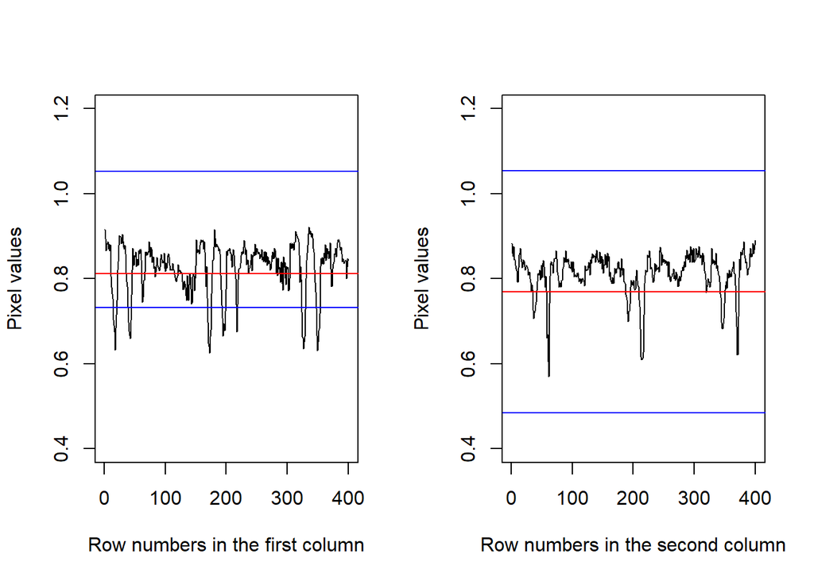

```
## integer(0)
```

```r
plot(img_g[2,],type = "line",ylim = bounds,ylab = "Pixel values",xlab ="Row numbers in the second column")+
  abline(h=mean_std_of_columns[2,1]+3*mean_std_of_columns[2,2],col="blue") +
  abline(h=mean_std_of_columns[2,1]-3*mean_std_of_columns[2,2],col="blue") +
  abline(h=mean_std_of_columns[2,1],col="red")
```

CONTROL CHARTS FOR THE FIRST TWO COLUMN

```r
image_new_for_columns<-img_g
```

```r
for(i in c(1:400)){
  UCL<-mean_std_of_columns[i,1]+3*mean_std_of_columns[i,2]
  LCL<-mean_std_of_columns[i,1]-3*mean_std_of_columns[i,2]
  for(j in c(1:400)){
    if((img_g[i,j]<LCL) || (img_g[i,j]> UCL)){
      image_new_for_columns[j,i]<-0
    }
  }
}
```

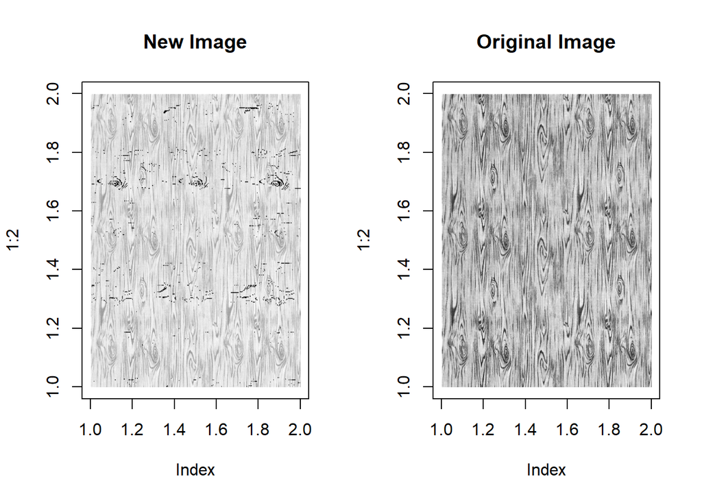

```r
par(mfrow = c(1,2))
plot(1:2, type='n',main = "New Image")
rasterImage(image_new_for_columns, 1, 1, 2, 2)
plot(1:2, type='n',main = "Original Image")
rasterImage(img_g, 1, 1, 2, 2)
```

#### We investigated the image columns by columns in the second part and rearranged the pixel values of the image according to 3 sigma control limits.As we expected when we look at a specific column, control limits become dependent to the pixel values of only that specific column.Because the mean and std values of columns are different from each other,we can say that the pixel values that are out of control affected by the vertical distributions of the corresponding pixels.However,the most important thing in here is the ways of the sapes on the image.The directions of the shapes are generally from top to bottom of the image and this really affects the std and mean values of columns and rows.Because of this reason,performing row operation gives much more out of control pixels according to the column operation.